# Final Project RFS

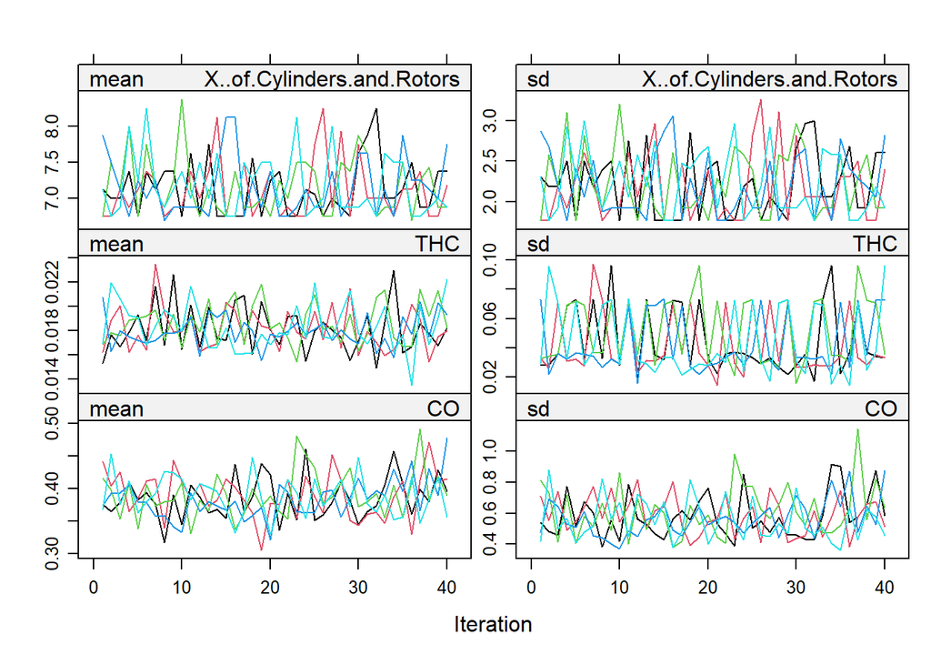

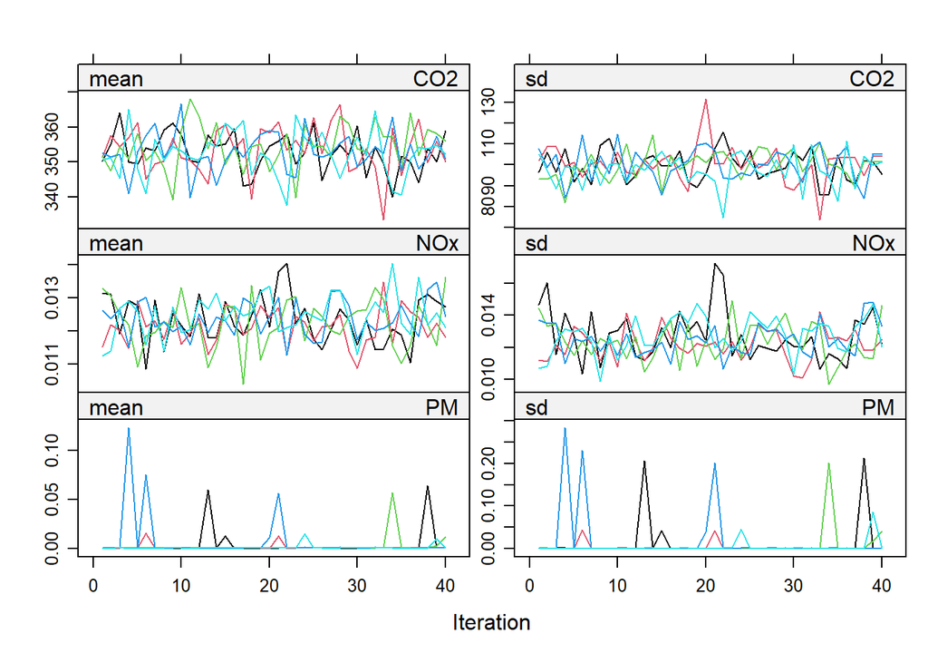

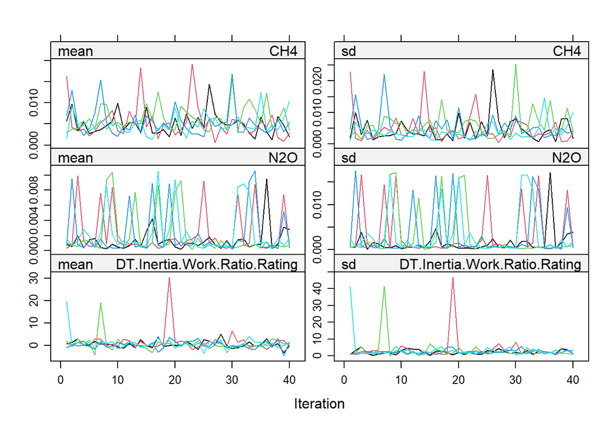

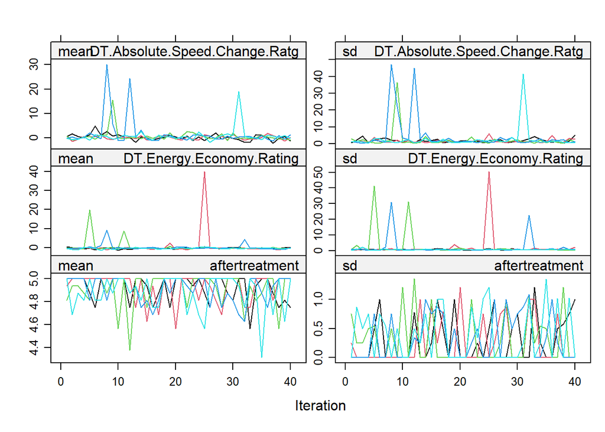

```r
# Extend number of iterations
imp.more <- mice.mids(imp.data, maxit = 30, print = F)
plot(imp.more)
```

“PM” and “DT Variables” still appear to be problematic, to no surprise. However, the imputation results for the rest of the predictors look great. We take special care in using “PM” and the “DT Variables” for the rest of the analyses.

Now we wish to choose our variables for linear regression based on correlation. We pool the imputations, average them out by variable and calculate the correlation coefficients to CO2 correspondingly.

```r
ave <- imp.more %>%
  mice::complete("long") %>%
  select_if(is.numeric) %>%
  group_by(.id) %>%
  summarise_all(.funs = mean)

head(ave)
```

```
## # A tibble: 6 × 26
##     .id  .imp Test.Veh.Displacement..L. Rated.Horsepower X..of.Cylinders.and.R…¹
##   <int> <dbl>                     <dbl>            <dbl>                   <dbl>
## 1     1     3                       4                503                       8
## 2     2     3                       4                503                       8
## 3     3     3                       5.2              715                      12
## 4     4     3                       5.2              715                      12
## 5     5     3                       4                550                       8
## 6     6     3                       4                550                       8
## # ℹ abbreviated name: ¹X..of.Cylinders.and.Rotors
## # ℹ 21 more variables: X..of.Gears <dbl>, Equivalent.Test.Weight..lbs.. <dbl>,
## #   Axle.Ratio <dbl>, N.V.Ratio <dbl>, THC <dbl>, CO <dbl>, CO2 <dbl>,
## #   NOx <dbl>, PM <dbl>, CH4 <dbl>, N2O <dbl>, RND_ADJ_FE <dbl>,
## #   DT.Inertia.Work.Ratio.Rating <dbl>, DT.Absolute.Speed.Change.Ratg <dbl>,
## #   DT.Energy.Economy.Rating <dbl>, Target.Coef.A..lbf. <dbl>,
## #   Target.Coef.B..lbf.mph. <dbl>, Target.Coef.C..lbf.mph..2. <dbl>, …
```

```r
cor <- ave %>%
    cor() %>%
    round(digits=2)
cor.co2 <- cor[,"CO2"] %>%
    na.omit() %>%
    sort(decreasing = T)

cor.co2.df <- data.frame(values = cor.co2)
head(cor.co2.df)
```

```
##                               values
## CO2                             1.00
## Rated.Horsepower                0.65
## Test.Veh.Displacement..L.       0.63
## X..of.Cylinders.and.Rotors      0.63
## NOx                             0.50
## Equivalent.Test.Weight..lbs..   0.47
```

Here we can select the numerical variables most correlated (coefficient of at least 0.4) to CO2 for use in our model.

Given the large number of predictors, stepwise regression takes considerable time to run

Count how many times each variable was selected:

```r
formulas <- lapply(fit$analyses, formula) # extract fitted model formulas
terms <- lapply(formulas, terms) # decompose model formulas into pieces
votes <- unlist(lapply(terms, labels)) # extract names of variables included in all models
table(votes) # count no. of time each variable in the 5 imputations
```

```
## votes
##                           CH4                            CO
##                             5                             5
##                     drive.sys Equivalent.Test.Weight..lbs..
##                             4                             5
##                     fuel.type                           NOx
##                             5                             5
##              Rated.Horsepower    Represented.Test.Veh.Model
##                             2                             3
##           Target.Coef.A..lbf.     Test.Veh.Displacement..L.
##                             5                             3
##                         trans                  trans.lockup
##                             2                             3
##                  Vehicle.Type    X..of.Cylinders.and.Rotors
##                             2                             5
##                   X..of.Gears
##                             5
```

We want to test the following predictors(that appear at least in 3 imputations), by nested model tests, if they are statistically significant: - vehicle model - vehicle displacement - transmission lockup

```r
fit.without.vm <- with(imp.more, lm(CO2 ~ CH4 + Equivalent.Test.Weight..lbs.. + CO + fuel.type + X..of.Cylinders.and.Rotors + NOx + Target.Coef.A..lbf. + X..of.Gears + drive.sys))

fit.with.vm <- with(imp.more, lm(CO2 ~ CH4 + Equivalent.Test.Weight..lbs.. + CO + fuel.type + X..of.Cylinders.and.Rotors + NOx + Target.Coef.A..lbf. + X..of.Gears + drive.sys + Represented.Test.Veh.Model))

D1(fit.with.vm,fit.without.vm)
```

```
##    test statistic df1      df2 dfcom      p.value        riv
##  1 ~~ 2  2.076044 721 3195.628  3204 1.176198e-41 0.04351811
```

The small p-value yields that the Wald test is significant, thus we keep “Represented Test Vehicle Model” in the model.

Test for “Test Vehicle Displacement”

```r
fit.with.vd <- with(imp.more, lm(CO2 ~ CH4 + Equivalent.Test.Weight..lbs.. + CO + fuel.type + X..of.Cylinders.and.Rotors + NOx + Target.Coef.A..lbf. + X..of.Gears + drive.sys + Represented.Test.Veh.Model + Test.Veh.Displacement..L.))

fit.without.vd <- with(imp.more, lm(CO2 ~ CH4 + Equivalent.Test.Weight..lbs.. + CO + fuel.type + X..of.Cylinders.and.Rotors + NOx + Target.Coef.A..lbf. + X..of.Gears + drive.sys + Represented.Test.Veh.Model))

D1(fit.with.vd,fit.without.vd)
```

```
##    test statistic df1 df2 dfcom   p.value       riv
##  1 ~~ 2 0.2545246   1   4  3203 0.6404307 0.3644444
```

In this instance, our p-value is large, thus we drop test vehicle displacement

Test for “Transmission Lockup”

```r
fit.with.tl <- with(imp.more, lm(CO2 ~ CH4 + Equivalent.Test.Weight..lbs.. + CO + fuel.type + X..of.Cylinders.and.Rotors + NOx + Target.Coef.A..lbf. + X..of.Gears + drive.sys + Represented.Test.Veh.Model + trans.lockup))

fit.without.tl <- with(imp.more, lm(CO2 ~ CH4 + Equivalent.Test.Weight..lbs.. + CO + fuel.type + X..of.Cylinders.and.Rotors + NOx + Target.Coef.A..lbf. + X..of.Gears + drive.sys + Represented.Test.Veh.Model))

D1(fit.with.tl, fit.without.tl)
```

```
##    test statistic df1 df2 dfcom    p.value       riv
##  1 ~~ 2  4.596315   1   4  3203 0.09865455 0.2728106
```

Similarly, we drop “Transmission Lockup” from the model.

## Multiple Regression Model

Fit the linear model (w/. test veh model) [complicated model, multinomial nature of “test veh model”]

```r
fit1.lm <- with(imp.more, lm(CO2 ~ CH4 + Equivalent.Test.Weight..lbs.. + CO + fuel.type + X..of.Cylinders.and.Rotors + NOx + Target.Coef.A..lbf. + X..of.Gears + drive.sys + Represented.Test.Veh.Model))

est1.lm <- pool(fit1.lm)
# summary(est1.lm)
```

Fit linear model (w/o. test veh model)

```r
fit1.lm.wo <- with(imp.more, lm(CO2 ~ CH4 + Equivalent.Test.Weight..lbs.. + CO + fuel.type + X..of.Cylinders.and.Rotors + NOx + Target.Coef.A..lbf. + X..of.Gears + drive.sys))

est1.lm.wo <- pool(fit1.lm.wo)
# summary(est1.lm.wo)
```

Compare R-squared

```r
pool.r.squared(fit1.lm)
```

```
##           est     lo 95     hi 95       fmi
## R^2 0.7774514 0.7636665 0.7905416 0.1788965
```

```r
pool.r.squared(fit1.lm.wo)
```

```
##           est     lo 95     hi 95       fmi
## R^2 0.6676972 0.6494623 0.6852103 0.1038824
```

We thus have a model (though extremely complex) that accounts for 77.7% of the variation in CO2.

With the methodology of mice(), there are currently no available ways to carry out regression model diagnostics to assess the quality of fit, besides our coefficient of determination.

Instead, there exists diagnostics to check MAR, MNAR and MCAR assumptions to assess the fit of the imputation model on missing data, such as the following:

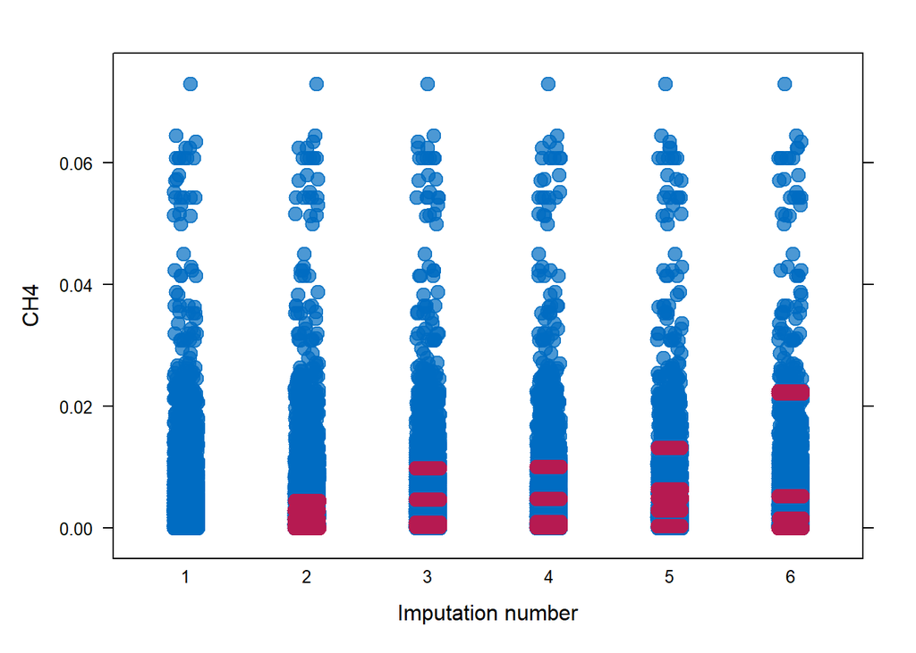

```r
stripplot(imp.more, CH4~.imp, pch=20, cex=2)
```

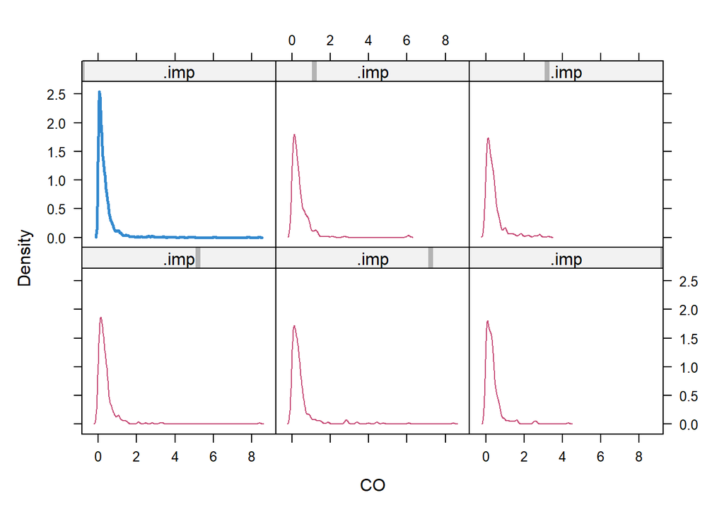

```r
densityplot(imp.more, ~CO | .imp)
```

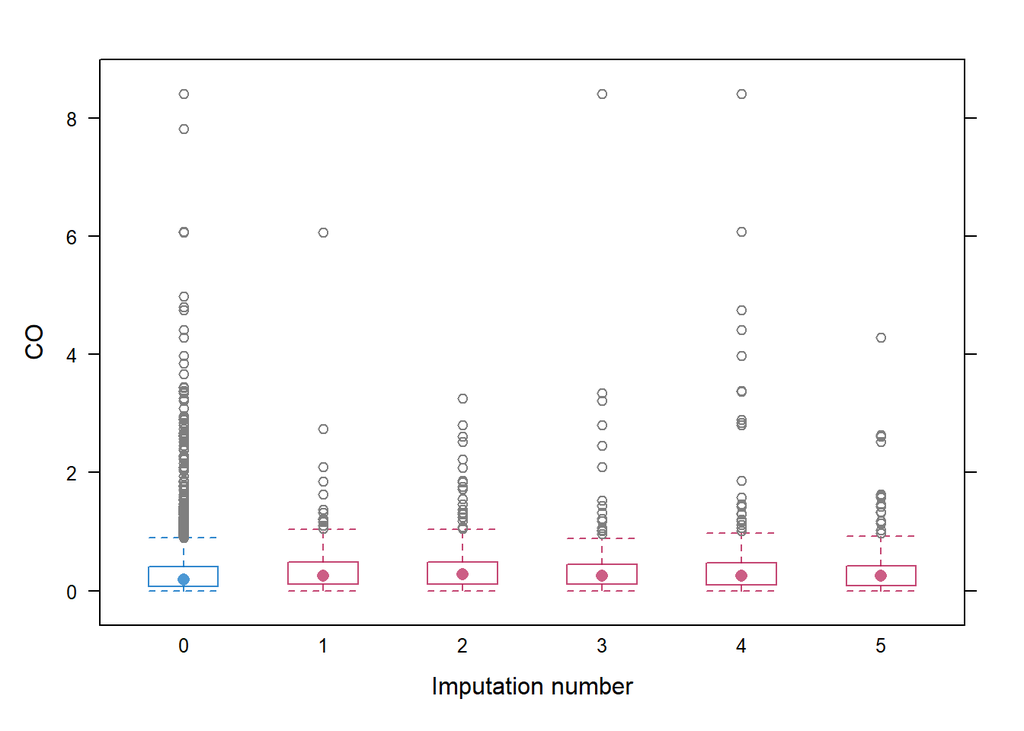

```r
# distribution of variable (densities) separated by imputed (red) and original observed (blue).

bwplot(imp.more, CO ~.imp)
```